# Exemplos de tipos de modelagem

- empírico
- análise dimensional
- ad-hoc
- mecanicista
  - heurístico
  - fundamental

## Tipos de modelagem

O processo de modelagem pode seguir vários caminhos:

- **empírico:** através da observação, seja de fenômenos reais, seja de experimentos controlados
- **análise dimensional:** baseado na análise das dimensões de quantidades envolvidas no fenômeno
- **ad-hoc:** introduzida sem muito fundamento e sem muita capacidade de generalização/extrapolação
- **mecanicista:** baseado em mecanismos envolvidos no fenômeno
  - **heurístico:** baseada em mecanismos qualitativos (e.g. os termos de interação entre duas espécies)
  - **fundamental:** baseado em relações/modelos bem estabelecidas e "precisos" (e.g. mecânica, termodinâmica, lei ação de massas)

Vale ressaltar que vários desses processos estão interligados.

## Modelagem empírica, alometria e a tilápia-do-nilo

- Como exemplo de modelagem empírica, vamos considerar um problema em alometria.
- **Alometria** trata do estudo entre as escalas de diversos atributos de um dado organismo. Por exemplo, relação entre tamanho do coração e a idade do indivíduo, entre o comprimento e a massa de um organismo, entre sua capacidade de locomoção e o tamanho dos membros de um animal -- asas, patas, pernas, barbatanas).

### Tilápia-do-nilo

- A tabela abaixo mostra dados da evolução da massa e do comprimento da *Tilápia-do-nilo* criada em cativeiro:

| Days of culture | 1 | 20 | 40 | 60 | 80 | 100 |
| --- | --- | --- | --- | --- | --- | --- |
| Massa (g) | 28.6±4.2 | 88.6±1.4 | 177.6±3.6 | 313.8±12.8 | 423.7±12.7 | 774.4±23.6 |
| Comprimento (cm) | 10.9±0.4 | 15.3±0.4 | 19.1±0.2 | 22.8±0.5 | 26.3±0.6 | 31.3±0.4 |

Fontes:

1. [Gayon, J. (2000) History of the Concept of Allometry. American Zoologist 40: 748-758](https://web.archive.org/web/20070930184104/http://www-ihpst.univ-paris1.fr/_sources/jgay_allometry.pdf)
2. [Shingleton, A. (2010) Allometry: The Study of Biological Scaling. Nature Education Knowledge 3(10):2](https://www.nature.com/scitable/knowledge/library/allometry-the-study-of-biological-scaling-13228439/)
3. [T. S. de Castro Silva, L. D. dos Santos, L. C. R. da Silva, M. Michelato, V. R. B. Furuya, W. M. Furuya, Length-weight relationship and prediction equations of body composition for growing-finishing cage-farmed Nile tilapia, R. Bras. Zootec. vol.44 no.4 Viçosa Apr. 2015](https://www.scielo.br/scielo.php?script=sci_arttext&pid=S1516-35982015000400133)

### Peso x comprimento

- Analisando os dados de comprimento e de peso da *tilápia-do-nilo*, obtemos a seguinte relação aproximada, que pode ser considerada um **lei empírica para o seu crescimento**: $$ y = 0.0203 x^{3.0604} $$
- Diversos estudos como esse, iniciados no final do século XIX, levaram a uma lei geral de escalas entre duas quantidades $y$ e $x$ na forma de uma lei de potência $$ y = bx^\alpha. $$

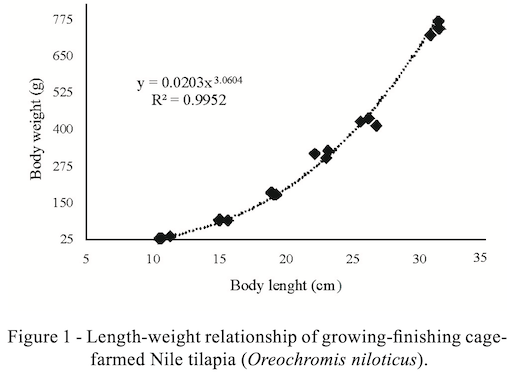

```julia
load(joinpath("img","NileTilapia_WeightLength_512x373.png"))
```

## Análise dimensional e o período de um pêndulo

- Na **análise dimensional**, busca-se obter uma relação entre os parâmetros envolvidos em um determinado problema.
- Usualmente, essa analise vem embutida com uma **hipótese de universalidade**, assumindo que o problema só depende dos parâmetros escolhidos.

### Pêndulo

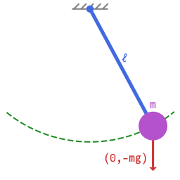

```julia
load(joinpath("img","pendulum_256x256.png"))
```

- Como exemplo, considere um pêndulo com haste de comprimento $\ell$ e massa $m$.
- Sob a ação da força gravitacional, cuja aceleração é denotada por $g$, o pêndulo oscila, com um período $\tau$.
- Buscamos entender como esse período depende dos outros parâmetros.
- A fórmula obtida pode inclusive ser utilizada para se estimar um dos parâmetros em função dos outros.

### Parâmetros e dimensões

- Cada sistema possui um **sistema de dimensões**.
- No caso de um sistema mecânico, temos as dimensões de *comprimento* $L$, *massa* $M$ e *tempo* $T$.
- Outros sistemas podem incluir unidades de temperatura $\Theta$, corrent elétrica $A$, intensidade luminosa $CD$, etc..
- Associado a isso, temos um **sistema de unidades**. Por exemplo, o sistema MKS utiliza as unidades de *metro*, *quilograma* e *segundo* para as dimensões de comprimento, massa e tempo, respectivamente, mas que não entram explicitamente na análise dimensional.
- Cada parâmetro está ligado a uma das dimensões.
- Denotamos a dimensão de uma quantidade colocando-a entre colchetes, e.g. $[m], [\ell], [g], [\tau]$.
- Assim, temos $$ [m]=M, \quad [\ell]=L, \quad [g]=L/T^2, [\tau]=T. $$

### Hipótese de universalidade e lei dimensional

- Como dito acima, a análise dimensional vem usualmente acompanhada de uma **hipótese de universalidade**.
- No caso do pêndulo, podemos fazer a hipótese de que o período é caracterizado apenas pela combinação dos parâmetros $\ell$, $m$ e $g$, por exemplo, $$\tau \propto m^a \ell^b g^c. $$
- Essa combinação tem dimensão $$ [ m^a \ell^b g^c] = M^a L^b \frac{L^c}{T^{2c}}. $$
- A única possibilidade disso ser de dimensão $T$ é com $$ a = 0, \quad b = -c = 1/2, \qquad c = -1/2. $$
- Assim, obtemos a relação $$ \tau \propto\sqrt{\frac{\ell}{g}}. $$
- O símbolo $\propto$ significa que uma quantidade é diretamente proporcional à outra, ou seja é um múltiplo constante da outra: $x \propto y$ é equivalente a $x = ky$ para algum $k\neq 0$.
- A constante de proporcionalidade, no entanto, não segue diretamente desssa análise.
- Além disso, desprezamos a resistência do ar, a variação na temperatura ambiente, a elasticidade da haste, o ângulo da oscilação, e outras parâmetros menos tangíveis.
- Mais adiante, veremos o Teorema de Buckinham-Pi, que formaliza mais essa análise.

## Heurístico

- Em uma modelagem heurística, aproveitamos algum mecanismo qualitativo que nos parece razoável para o problema.
- Um ótimo exemplo é o de dinâmica populacional.
- Seja de um ou mais organismos, interagindo com o meio e entre si.

### Dinâmica populacional de um único organismos

- Imaginemos uma situação controlada em laboratório, e.g. em um experimento em um placa de Petri.
- Seja $x=x(t)$ é a população (e.g. número de células) de um organismo (e.g. fungo, bactéria) em função do tempo.
- O organismo pode se multiplicar de diversas maneiras (e.g. divisão celular, brotamento).
- Tipicamente, cada organismo dá origem a um ou mais novos organismos a certos intervalos de tempo.
- Quanto mais organismos em um determinado instante, proporcionalmente mais novos organismos são gerados.
- E quanto maior o tempo decorrido, proporcionalmente mais novos organismos são gerados.
- Isso nos leva a relação $\Delta x \propto x\Delta t$.

### Taxa temporal de evolução

- A relação $\Delta x \propto x\Delta t$ é imprecisa, pois temos $x=x(t)$ do lado direito afetando toda a evolução durante o intervalo $\Delta t$.
- Isso não leva em consideração que, ao longo desse intervalo de tempo, pode já haver novos organismos participando de mais gerações, caso esse intervalo seja muito grande.
- Assim, é adequado considerarmos a **taxa temporal** de evolução, obtida tomando-se o limite quando $\Delta t \rightarrow 0$: $$ \frac{\text{d} x}{\text{d} t} \propto x $$
- Isso nos dá uma lei **heurística** para o crescimento do organismo.

### Relação com lei empírica

- Observe que a solução é $x(t) = x(0) e^{kt}$, onde $k$ é a constante de proporcionalidade na relação anterior.
- Essa solução poderia ter sido obtida experimentalmente, medindo-se a população do organismo, para vários tipos de bactérios e fungos.
- Nesse caso, teríamos a **lei empírica** $\log x(t) - \log x(0) \propto t$, válida pra qualquer organismo simples desse tipo.
- Ou mais explicitamente, $x(t) = x(0) e^{kt}$, com $k$ dependendo do organismo.

## Ad-hoc - crescimento com limitação

- Modelagem **ad-hoc** é utilizada quando não temos algum mecanismo razoável para considerar algum aspecto da modelagem.
- Ela é muito utilizada em combinação com outras modelagens, para complementar alguma informação faltante.
- No caso de crescimento populacional, por exemplo, isso pode aparecer ao considerarmos que o organismo depende de nutrientes para se desenvolver e gerar novos organismos.
- Podemos imaginar situações em que essa quantidade de nutrientes é limitada, como em um placa de Petri.
- Assim, o crescimento será afetado pelo tamanho da população, com a taxa de crescimento diminuindo conforme a população aumenta.

### Relação com lei empírica

- Podemos (e devemos) usar dados reais para **validar** o modelo *ad-hoc* acima.
- Mas também podemos partir dos dados e deduzir o modelo $x'=\alpha x - \beta x^2$ através do ajuste de parâmetros.
- Dessa maneira, essa forma do modelo é considerado um *ansatz*.
- De acordo com o dicionário Oxford, ansatz é uma hipótese que é feita para facilitar encontrar a solução de um problema.
- Coletando dados esses dados de crescimento em situações de recursos limitados, para uma série de organismos, podemos verificar e concluir essa lei de forma **empírica**.

### Crescimento limitado com termo quadrático

- Um hipótese comum é assumir que isso é afetado por um termo de ordem quadrática, levando-nos à equação logística: $$ \frac{\text{d}x}{\text{d}t} = \alpha x - \beta x^2 \quad \Longleftrightarrow \quad \frac{\text{d}x}{\text{d}t} = \alpha ( 1 - \frac{\beta}{\alpha} x) x. $$
- Observe que para $0< x \ll \alpha/\beta$, o termo quadrático é desprezível, e obtemos o crescimento natural.
- Mas para $x \sim \alpha/\beta$, o termo quadrático reduz consideravelmente a taxa de crescimento.
- Observe, no entanto, que isso foi uma dedução essencialmente matemática, em termos de ordem de grandeza, sem levar em consideração algum mecanismo especial. O mesmo efeito seria alcançado com qualquer potência maior $p>1$, não necessariamente $p=2$. Nesse sentido, foi uma escolha *ad-hoc*.

## Fundamental

- A Mecânica Clássica é um perfeito exemplo disso.
- O modelo dado pela equação $$ m\ddot x = F(x,\dot x) $$ vale em geral, desde que sob condições macroscópicas mas sem exageros astronômicos e em velocidades bem mais baixas do que a velocidade da luz.
- Em alguns casos, é preciso considerar a variação de massa do objeto (e.g. foguete)
- Em outras situações, os modelos de relatividade restrita, relatividade geral, mecânica quântica, entre outros, são necessários.
- Muitos modelos considerados fundamentais surgiram baseados também em análises empíricas, dimensionais, com termos ad-hoc e/ou de forma heurística, mas ganharam solidez e confirmação com o tempo.